# INN Hotels Project

## Building a Decision Tree model

```python
# Libraries to build decision tree classifier
from sklearn.tree import DecisionTreeClassifier
from sklearn import tree

# To tune different models
from sklearn.model_selection import GridSearchCV
# To perform statistical analysis
import scipy.stats as stats

# To get diferent metric scores
from sklearn.metrics import (
    f1_score,
    accuracy_score,
    recall_score,
    precision_score,
    confusion_matrix,
    plot_confusion_matrix,
    make_scorer,
)


model = DecisionTreeClassifier(criterion="gini", random_state=1)
model.fit(X_train2, y_train)
```

```
DecisionTreeClassifier(random_state=1)
```

```python
# defining a function to compute different metrics to check performance of a classification model built using sklearn
def model_performance_classification_sklearn(model, predictors, target):
    """
    Function to compute different metrics to check classification model performance

    model: classifier
    predictors: independent variables
    target: dependent variable
    """

    # predicting using the independent variables
    pred = model.predict(predictors)

    acc = accuracy_score(target, pred)  # to compute Accuracy
    recall = recall_score(target, pred)  # to compute Recall
    precision = precision_score(target, pred)  # to compute Precision
    f1 = f1_score(target, pred)  # to compute F1-score

    # creating a dataframe of metrics
    df_perf = pd.DataFrame(
        {"Accuracy": acc, "Recall": recall, "Precision": precision, "F1": f1,},
        index=[0],
    )

    return df_perf
```

```python
def confusion_matrix_sklearn(model, predictors, target):
    """
    To plot the confusion_matrix with percentages

    model: classifier
    predictors: independent variables
    target: dependent variable
    """
    y_pred = model.predict(predictors)
    cm = confusion_matrix(target, y_pred)
    labels = np.asarray(
        [
            ["{0:0.0f}".format(item) + "\n{0:.2%}".format(item / cm.flatten().sum())]
            for item in cm.flatten()
        ]
    ).reshape(2, 2)

    plt.figure(figsize=(6, 4))
    sns.heatmap(cm, annot=labels, fmt="")
    plt.ylabel("True label")
    plt.xlabel("Predicted label")
```

```python
decision_tree_perf_train = model_performance_classification_sklearn(
    model, X_train2, y_train
)
decision_tree_perf_train
```

|  | Accuracy | Recall | Precision | F1 |
| --- | --- | --- | --- | --- |
| 0 | 0.990509 | 0.991896 | 0.993939 | 0.992917 |

- Accuracy, recall, precision, and F1 scores are all above 99% which may be indicative of overfitting.

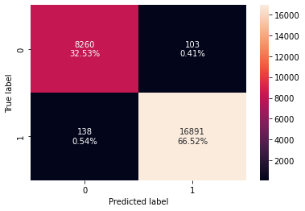

```python
confusion_matrix_sklearn(model, X_train2, y_train)
```

```python
decision_tree_perf_test = model_performance_classification_sklearn(
    model, X_test2, y_test
)
decision_tree_perf_test
```

|  | Accuracy | Recall | Precision | F1 |
| --- | --- | --- | --- | --- |
| 0 | 0.860149 | 0.889553 | 0.902301 | 0.895882 |

## Do we need to prune the tree?

Pruning the tree is necessary as it is overfitting the training data.

```python
# Choose the type of classifier.
estimator = DecisionTreeClassifier(random_state=1)

# Grid of parameters to choose from

parameters = {
    "max_depth": [np.arange(2, 50, 5), None],
    "criterion": ["entropy", "gini"],
    "splitter": ["best", "random"],
    "min_impurity_decrease": [0.000001, 0.00001, 0.0001],
}

# Type of scoring used to compare parameter combinations
acc_scorer = make_scorer(recall_score)

# Run the grid search
grid_obj = GridSearchCV(estimator, parameters, scoring=acc_scorer, cv=5)
grid_obj = grid_obj.fit(X_train2, y_train)

# Set the clf to the best combination of parameters
estimator = grid_obj.best_estimator_

# Fit the best algorithm to the data.
estimator.fit(X_train2, y_train)
```

```
DecisionTreeClassifier(min_impurity_decrease=0.0001, random_state=1)
```

```python
decision_tree_tune_perf_train = model_performance_classification_sklearn(
    estimator, X_train2, y_train
)
decision_tree_tune_perf_train
```

|  | Accuracy | Recall | Precision | F1 |
| --- | --- | --- | --- | --- |
| 0 | 0.890517 | 0.937166 | 0.90322 | 0.91988 |

- The F1 score has gone down but this may be a positive thing.

```python
decision_tree_tune_perf_test = model_performance_classification_sklearn(
    estimator, X_test2, y_test
)

decision_tree_tune_perf_test
```

|  | Accuracy | Recall | Precision | F1 |
| --- | --- | --- | --- | --- |
| 0 | 0.87678 | 0.92664 | 0.894909 | 0.910499 |

- The F1 scores of the two models are almost the same now, which means that pre-pruning reduced the chance of overfitting.

```
['no_of_adults', 'no_of_weekend_nights', 'no_of_week_nights', 'lead_time', 'arrival_year', 'arrival_month', 'arrival_date', 'avg_price_per_room', 'no_of_special_requests', 'market_segment_type_Corporate', 'market_segment_type_Offline', 'market_segment_type_Online', 'type_of_meal_plan_Meal Plan 2', '…
```

[figure not shown]

```python
# vizualising the decision tree:
column_names = list(X.columns)
feature_names = column_names
print(feature_names)

plt.figure(figsize=(15, 12))

tree.plot_tree(
    estimator,
    feature_names=feature_names,
    filled=True,
    fontsize=9,
    node_ids=True,
    class_names=True,
)
plt.show()
```

The decision tree is still rather complex and could probably benefit from further pruning.

```python
# cost complexity pruning:
clf = DecisionTreeClassifier(random_state=1)
path = clf.cost_complexity_pruning_path(X_train, y_train)
ccp_alphas, impurities = path.ccp_alphas, path.impurities
```

```python
pd.DataFrame(path)
```

|  | ccp_alphas | impurities |
| --- | --- | --- |
| 0 | 0.000000e+00 | 0.008107 |
| 1 | 1.219272e-07 | 0.008107 |
| 2 | 1.842455e-07 | 0.008107 |
| 3 | 2.895771e-07 | 0.008107 |
| 4 | 4.688391e-07 | 0.008108 |
| ... | ... | ... |
| 1397 | 4.542523e-03 | 0.280576 |
| 1398 | 6.769755e-03 | 0.294116 |
| 1399 | 1.658770e-02 | 0.310703 |
| 1400 | 1.815996e-02 | 0.365183 |
| 1401 | 7.657789e-02 | 0.441761 |

1402 rows × 2 columns

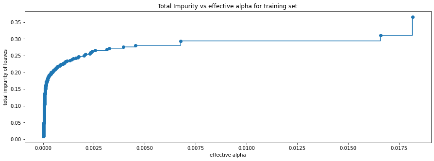

```python
fig, ax = plt.subplots(figsize=(15, 5))
ax.plot(ccp_alphas[:-1], impurities[:-1], marker="o", drawstyle="steps-post")
ax.set_xlabel("effective alpha")
ax.set_ylabel("total impurity of leaves")
ax.set_title("Total Impurity vs effective alpha for training set")
plt.show()
```

```python
# train a decision tree using the effective alphas:
clfs = []
for ccp_alpha in ccp_alphas:
    clf = DecisionTreeClassifier(random_state=1, ccp_alpha=ccp_alpha)
    clf.fit(X_train2, y_train)
    clfs.append(clf)
print(
    "Number of nodes in the last tree is: {} with ccp_alpha: {}".format(
        clfs[-1].tree_.node_count, ccp_alphas[-1]
    )
)
```

[output not shown]

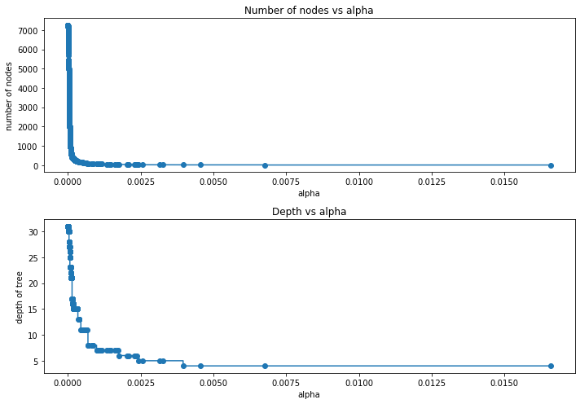

```python
clfs = clfs[:-1]
ccp_alphas = ccp_alphas[:-1]

node_counts = [clf.tree_.node_count for clf in clfs]
depth = [clf.tree_.max_depth for clf in clfs]
fig, ax = plt.subplots(2, 1, figsize=(10, 7))
ax[0].plot(ccp_alphas, node_counts, marker="o", drawstyle="steps-post")
ax[0].set_xlabel("alpha")
ax[0].set_ylabel("number of nodes")
ax[0].set_title("Number of nodes vs alpha")
ax[1].plot(ccp_alphas, depth, marker="o", drawstyle="steps-post")
ax[1].set_xlabel("alpha")
ax[1].set_ylabel("depth of tree")
ax[1].set_title("Depth vs alpha")
fig.tight_layout()
```